# Quantium Virtual Internship - Retail Strategy and Analytics - Task 1

# Solution template for Task 1

This file is a solution template for the Task 1 of the Quantium Virtual Internship. It will walk you through the analysis, providing the scaffolding for your solution with gaps left for you to fill in yourself.

Look for comments that say “over to you” for places where you need to add your own code!

Often, there will be hints about what to do or what function to use in the text leading up to a code block - if you need a bit of extra help on how to use a function, the internet has many excellent resources on R coding, which you can find using your favourite search engine.

## Load required libraries and datasets

Note that you will need to install these libraries if you have never used these before.

```r
#### Example code to install packages
#install.packages("data.table")
#install.packages("ggplot2")
#install.packages("ggmosaic")
#install.packages("readr")
#install.packages("stringr")
#install.packages("dplyr")

#### Load required libraries
library(data.table)
library(ggplot2)
library(ggmosaic)
library(readr)
library(stringr)
library(dplyr)
library(tidyr)

#### Point the filePath to where you have downloaded the datasets to and
#### assign the data files to data.tables
# over to you! fill in the path to your working directory. If you are on a Windows
#machine, you will need to use forward slashes (/) instead of backshashes (\)

filePath <- paste(as.character(getwd()), "/", sep="")

transactionData <- fread(paste0(filePath,"QVI_transaction_data.csv"))
customerData <- fread(paste0(filePath,"QVI_purchase_behaviour.csv"))
```

## Exploratory data analysis

The first step in any analysis is to first understand the data. Let’s take a look at each of the datasets provided.

### Examining transaction data

We can use `str()` to look at the format of each column and see a sample of the data. As we have read in the dataset as a `data.table` object, we can also run `transactionData` in the console to see a sample of the data or use `head(transactionData)` to look at the first 10 rows. Let’s check if columns we would expect to be numeric are in numeric form and date columns are in date format.

```r
str(transactionData)
```

```
Classes ‘data.table’ and 'data.frame':  264836 obs. of  8 variables:
 $ DATE          : int  43390 43599 43605 43329 43330 43604 43601 43601 43332 43330 ...
 $ STORE_NBR     : int  1 1 1 2 2 4 4 4 5 7 ...
 $ LYLTY_CARD_NBR: int  1000 1307 1343 2373 2426 4074 4149 4196 5026 7150 ...
 $ TXN_ID        : int  1 348 383 974 1038 2982 3333 3539 4525 6900 ...
 $ PROD_NBR      : int  5 66 61 69 108 57 16 24 42 52 ...
 $ PROD_NAME     : chr  "Natural Chip        Compny SeaSalt175g" "CCs Nacho Cheese    175g" "Smiths Crinkle Cut  Chips Chicken 170g" "Smiths Chip Thinly  S/Cream&Onion 175g" ...
 $ PROD_QTY      : int  2 3 2 5 3 1 1 1 1 2 ...
 $ TOT_SALES     : num  6 6.3 2.9 15 13.8 5.1 5.7 3.6 3.9 7.2 ...
 - attr(*, ".internal.selfref")=<externalptr>
```

We can see that the date column is in an integer format. Let’s change this to a date format.

```r
#### Convert DATE column to a date format
#### A quick search online tells us that CSV and Excel integer dates begin on 30 Dec 1899
transactionData$DATE <- as.Date(transactionData$DATE, origin = "1899-12-30")
```

We should check that we are looking at the right products by examining PROD_NAME.

```r
### Examine PROD_NAME

## Checking is there are products that are not chips

productWords<- data.table(unlist(strsplit(unique(transactionData[,PROD_NAME]), " ")))
setnames(productWords, 'words')

## Removing special characters and digits

productWords <- lapply(productWords, function(x) gsub("[^[:alnum:]0:9]", " ", x))

## Removing Salsa Products

transactionData[, SALSA := grepl("salsa", tolower(PROD_NAME))]
transactionData <- transactionData[SALSA == FALSE, ][, SALSA := NULL]
```

Next, we can use `summary()` to check summary statistics such as mean, min and max values for each feature to see if there are any obvious outliers in the data and if there are any nulls in any of the columns (`NA's : number of nulls` will appear in the output if there are any nulls).

```r
summary(transactionData)
```

```
      DATE              STORE_NBR     LYLTY_CARD_NBR        TXN_ID           PROD_NBR       PROD_NAME
 Min.   :2018-07-01   Min.   :  1.0   Min.   :   1000   Min.   :      1   Min.   :  1.00   Length:246742
 1st Qu.:2018-09-30   1st Qu.: 70.0   1st Qu.:  70015   1st Qu.:  67569   1st Qu.: 26.00   Class :character
 Median :2018-12-30   Median :130.0   Median : 130367   Median : 135183   Median : 53.00   Mode  :character
 Mean   :2018-12-30   Mean   :135.1   Mean   : 135531   Mean   : 135131   Mean   : 56.35
 3rd Qu.:2019-03-31   3rd Qu.:203.0   3rd Qu.: 203084   3rd Qu.: 202654   3rd Qu.: 87.00
 Max.   :2019-06-30   Max.   :272.0   Max.   :2373711   Max.   :2415841   Max.   :114.00
    PROD_QTY         TOT_SALES
 Min.   :  1.000   Min.   :  1.700
 1st Qu.:  2.000   1st Qu.:  5.800
 Median :  2.000   Median :  7.400
 Mean   :  1.908   Mean   :  7.321
 3rd Qu.:  2.000   3rd Qu.:  8.800
 Max.   :200.000   Max.   :650.000
```

There are no nulls in the columns but product quantity appears to have an outlier which we should investigate further. Let’s investigate further the case where 200 packets of chips are bought in one transaction.

```r
## Filter the outlier for which the product quantity is 200
filter(transactionData, PROD_QTY == 200)
```

| DATE | STORE_NBR | LYLTY_CARD_NBR | TXN_ID | PROD_NBR | PROD_NAME | PROD_QTY | TOT_SALES |
| --- | --- | --- | --- | --- | --- | --- | --- |
| 2018-08-19 | 226 | 226000 | 226201 | 4 | Dorito Corn Chp Supreme 380g | 200 | 650 |
| 2019-05-20 | 226 | 226000 | 226210 | 4 | Dorito Corn Chp Supreme 380g | 200 | 650 |

```r
transactionData[transactionData$PROD_QTY == 200]
```

| DATE | STORE_NBR | LYLTY_CARD_NBR | TXN_ID | PROD_NBR | PROD_NAME | PROD_QTY | TOT_SALES |
| --- | --- | --- | --- | --- | --- | --- | --- |
| 2018-08-19 | 226 | 226000 | 226201 | 4 | Dorito Corn Chp Supreme 380g | 200 | 650 |
| 2019-05-20 | 226 | 226000 | 226210 | 4 | Dorito Corn Chp Supreme 380g | 200 | 650 |

There are two transactions where 200 packets of chips are bought in one transaction and both of these transactions were by the same customer.

```r
#### Let's see if the customer has had other transactions
filter(transactionData, LYLTY_CARD_NBR == 226000)
```

| DATE | STORE_NBR | LYLTY_CARD_NBR | TXN_ID | PROD_NBR | PROD_NAME | PROD_QTY | TOT_SALES |
| --- | --- | --- | --- | --- | --- | --- | --- |
| 2018-08-19 | 226 | 226000 | 226201 | 4 | Dorito Corn Chp Supreme 380g | 200 | 650 |
| 2019-05-20 | 226 | 226000 | 226210 | 4 | Dorito Corn Chp Supreme 380g | 200 | 650 |

It looks like this customer has only had the two transactions over the year and is not an ordinary retail customer. The customer might be buying chips for commercial purposes instead. We’ll remove this loyalty card number from further analysis.

```r
#### Filter out the customer based on the loyalty card number
# Over to you!
transactionData <- filter(transactionData, LYLTY_CARD_NBR != 226000)

#### Re-examine transaction data
# Over to you!
summary(transactionData)
```

```
      DATE              STORE_NBR     LYLTY_CARD_NBR        TXN_ID           PROD_NBR       PROD_NAME
 Min.   :2018-07-01   Min.   :  1.0   Min.   :   1000   Min.   :      1   Min.   :  1.00   Length:246740
 1st Qu.:2018-09-30   1st Qu.: 70.0   1st Qu.:  70015   1st Qu.:  67569   1st Qu.: 26.00   Class :character
 Median :2018-12-30   Median :130.0   Median : 130367   Median : 135182   Median : 53.00   Mode  :character
 Mean   :2018-12-30   Mean   :135.1   Mean   : 135530   Mean   : 135130   Mean   : 56.35
 3rd Qu.:2019-03-31   3rd Qu.:203.0   3rd Qu.: 203083   3rd Qu.: 202652   3rd Qu.: 87.00
 Max.   :2019-06-30   Max.   :272.0   Max.   :2373711   Max.   :2415841   Max.   :114.00
    PROD_QTY       TOT_SALES
 Min.   :1.000   Min.   : 1.700
 1st Qu.:2.000   1st Qu.: 5.800
 Median :2.000   Median : 7.400
 Mean   :1.906   Mean   : 7.316
 3rd Qu.:2.000   3rd Qu.: 8.800
 Max.   :5.000   Max.   :29.500
```

That’s better. Now, let’s look at the number of transaction lines over time to see if there are any obvious data issues such as missing data.

```r
#### Count the number of transactions by date
# Over to you! Create a summary of transaction count by date.
transactions_by_day <-
  transactionData %>%
  group_by(DATE) %>%
  arrange(DATE)  %>%
  summarize(N = n ()) %>%
  print
```

| DATE | N |
| --- | --- |
| 2018-07-01 | 663 |
| 2018-07-02 | 650 |
| 2018-07-03 | 674 |
| 2018-07-04 | 669 |
| 2018-07-05 | 660 |
| 2018-07-06 | 711 |
| 2018-07-07 | 695 |
| 2018-07-08 | 653 |
| 2018-07-09 | 692 |
| 2018-07-10 | 650 |

[output cut: 354 more lines]

There’s only 364 rows, meaning only 364 dates which indicates a missing date. Let’s create a sequence of dates from 1 Jul 2018 to 30 Jun 2019 and use this to create a chart of number of transactions over time to find the missing date.

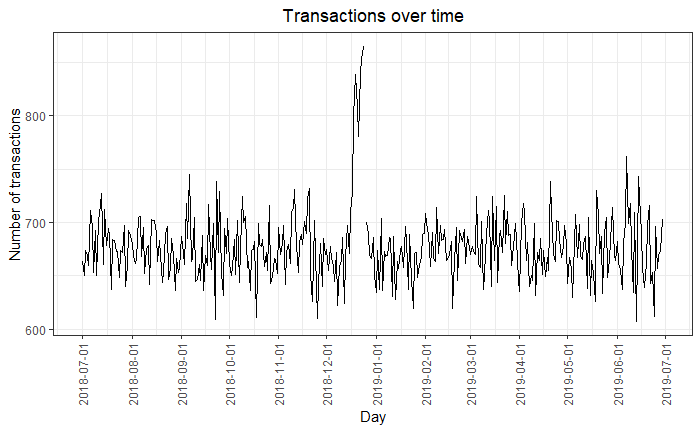

```r
#### Create a sequence of dates and join this the count of transactions by date
# Over to you - create a column of dates that includes every day from 1 Jul 2018 to
#30 Jun 2019, and join it onto the data to fill in the missing day.
datcol <- as.data.frame (seq(from = as.Date("2018-07-01"), to = as.Date("2019-06-30"), by = 'day'))
setnames(datcol, 'DATE')

## Joining the column of dates with the date to fill the missing date

transactions_by_day <- full_join(datcol, transactions_by_day, by = "DATE")

#### Setting plot themes to format graphs
theme_set(theme_bw())
theme_update(plot.title = element_text(hjust = 0.5))

#### Plot transactions over time
ggplot(transactions_by_day, aes(x = DATE, y = N)) +
geom_line() +
labs(x = "Day", y = "Number of transactions", title = "Transactions over time") +
scale_x_date(breaks = "1 month") +
theme(axis.text.x = element_text(angle = 90, vjust = 0.5))
```

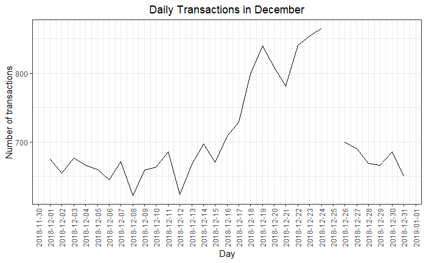

```r
## Getting the number of transaction in December

december <- seq(from = as.Date("2018-12-01"), to = as.Date("2018-12-31"), by = 'day')
trans_december <- filter(transactions_by_day, DATE %in% december)

## Plotting transaction in December

ggplot(trans_december, aes(x = DATE, y = N)) +
  geom_line() +
  labs(x = "Day", y = "Number of transactions", title = "Daily Transactions in December") +
  scale_x_date(breaks = "1 day") +
  theme(axis.text.x = element_text(angle = 90, vjust = 0.5))
```

We can see that the increase in sales occurs in the lead-up to Christmas and that there are zero sales on Christmas day itself. This is due to shops being closed on Christmas day.

Now that we are satisfied that the data no longer has outliers, we can move on to creating other features such as brand of chips or pack size from PROD_NAME. We will start with pack size.

```r
#### Pack size
#### We can work this out by taking the digits that are in PROD_NAME
transactionData[, PACK_SIZE := parse_number(PROD_NAME)]
```

[output not shown]

```r
#### Always check your output
#### Let's check if the pack sizes look sensible
transactionData[, .N, PACK_SIZE][order(PACK_SIZE)]
```

| PACK_SIZE | N |
| --- | --- |
| 70 | 1507 |
| 90 | 3008 |
| 110 | 22387 |
| 125 | 1454 |
| 134 | 25102 |
| 135 | 3257 |
| 150 | 40203 |
| 160 | 2970 |
| 165 | 15297 |
| 170 | 19983 |

[output cut: 10 more lines]

The largest size is 380g and the smallest size is 70g - seems sensible!

```r
transactions_by_size <-
  transactionData %>%
  group_by(PACK_SIZE) %>%
  arrange(PACK_SIZE)  %>%
  summarize(N = n ()) %>%
  print
```

| PACK_SIZE | N |
| --- | --- |
| 70 | 1507 |
| 90 | 3008 |
| 110 | 22387 |
| 125 | 1454 |
| 134 | 25102 |
| 135 | 3257 |
| 150 | 40203 |
| 160 | 2970 |
| 165 | 15297 |
| 170 | 19983 |

[output cut: 10 more lines]

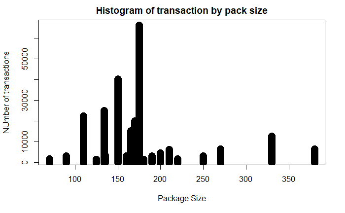

```r
#### Let's plot a histogram of PACK_SIZE since we know that it is a categorical variable and not a continuous variable even though it is numeric.
# Over to you! Plot a histogram showing the number of transactions by pack size.
plot(transactions_by_size$PACK_SIZE, transactions_by_size$N,
     main = "Histogram of transaction by pack size",
     xlab = "Package Size",
     ylab = "NUmber of transactions",
     type = "h", lwd = 15)
```

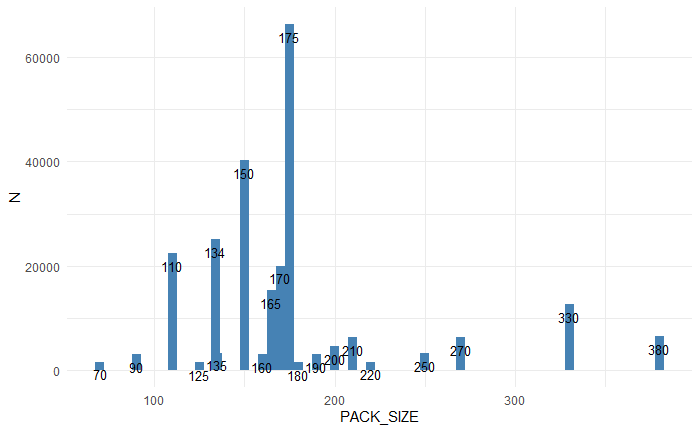

```r
ggplot(data = transactions_by_size, aes(x=PACK_SIZE,y=N))+
  geom_bar(stat="identity", fill="steelblue", width = 5)+
  geom_text(aes(label=PACK_SIZE), vjust=1.6, color="black", size=3.5)+
  theme_minimal()
```

Pack sizes created look reasonable. Now to create brands, we can use the first word in PROD_NAME to work out the brand name…

```r
#### Brands
# Over to you! Create a column which contains the brand of the product, by extracting it from the product name.
transactionData <- mutate(transactionData, BRAND = word(transactionData$PROD_NAME, 1))
```

```r
#### Checking brands
# Over to you! Check the results look reasonable.
transactionData[BRAND == "RED", BRAND := "RRD"]
brandname <- word(transactionData$PROD_NAME, 1)
unique(brandname)
```

```
 [1] "Natural"    "CCs"        "Smiths"     "Kettle"     "Grain"      "Doritos"    "Twisties"   "WW"
 [9] "Thins"      "Burger"     "NCC"        "Cheezels"   "Infzns"     "Red"        "Pringles"   "Dorito"
[17] "Infuzions"  "Smith"      "GrnWves"    "Tyrrells"   "Cobs"       "French"     "RRD"        "Tostitos"
[25] "Cheetos"    "Woolworths" "Snbts"      "Sunbites"
```

```r
transactionData[BRAND == "Infuzions", BRAND := "Infzns"]
unique(transactionData$BRAND)
```

```
 [1] "Natural"    "CCs"        "Smiths"     "Kettle"     "Grain"      "Doritos"    "Twisties"   "WW"
 [9] "Thins"      "Burger"     "NCC"        "Cheezels"   "Infzns"     "Red"        "Pringles"   "Dorito"
[17] "Smith"      "GrnWves"    "Tyrrells"   "Cobs"       "French"     "RRD"        "Tostitos"   "Cheetos"
[25] "Woolworths" "Snbts"      "Sunbites"
```

### Examining customer data

Now that we are happy with the transaction dataset, let’s have a look at the customer dataset

```r
#### Examining customer data
# Over to you! Do some basic summaries of the dataset, including distributions of any key columns.
summary(customerData)
```

```
 LYLTY_CARD_NBR     LIFESTAGE         PREMIUM_CUSTOMER
 Min.   :   1000   Length:72637       Length:72637
 1st Qu.:  66202   Class :character   Class :character
 Median : 134040   Mode  :character   Mode  :character
 Mean   : 136186
 3rd Qu.: 203375
 Max.   :2373711
```

```r
customerData <- separate( data = customerData, col = LIFESTAGE, into = c("LIFESTAGE", "MARITAL_STATUS"))
```

[output not shown]

```r
#### Merge transaction data to customer data
data <- merge(transactionData, customerData, all.x = TRUE)
```

```r
# Over to you! See if any transactions did not have a matched customer.
table(is.na(data))
```

```
  FALSE    TRUE
3161189   46431
```

```r
fwrite(data, paste0(filePath,"QVI_data.csv"))
```

Data exploration is now complete!